# P337: RNA-seq data cleaning

Bronchial lavage (BAL) and brushing (BE) pre/post allergen challenge

Kim Dill-McFarland, kadm@uw.edu

version December 21, 2023

# Background

The purpose of this workflow is to complete basic data cleaning of metadata and RNA-seq libraries. This includes 1) combining batches, 2) removing low coverage libraries, 3) filtering rare genes, 4) removing outlying libraries, and 5) normalizing counts to log2CPM.

# Setup

Load packages

```r
# Data manipulation and figures
library(tidyverse)
  # Modify ggplot figures to non-overlapping text labels
  library(ggrepel)
  # Modify ggplot data order within facets
  library(drlib)
  # Plot log scales
  library(scales)
  #Multi-panel figures
  library(cowplot)
# Reading Excel files
library(readxl)
# Working with dates
library(lubridate)

# Empirical analysis of digital gene expression data
## Data normalization
library(edgeR)

# Print pretty table to knit file
library(knitr)
library(kableExtra)
  options(knitr.kable.NA = '')

#Create 'not in' operator
`%notin%` <- Negate(`%in%`)
```

Load scripts

```r
#BRI RNAseq file import and cleaning
source("https://raw.githubusercontent.com/kdillmcfarland/R_bioinformatic_scripts/master/RNAseq_cleanup.R")
#Rare gene filter
source("https://raw.githubusercontent.com/kdillmcfarland/R_bioinformatic_scripts/master/RNAseq_rare_gene_filter.R")
```

Set seed

```r
set.seed(4389)
```

# Read in and format data

## Counts and metadata

Perform basic RNA-seq data cleaning with script `RNAseq_cleanup.R`. This reads in and combines library quality metrics in `summary-data` and `Final Annotation` as well as the raw counts in genes.

```r
#Leave columns as defaults
clean.RNAseq(data.dir="data_raw/RNAseq.batch2/")
## Rename to not overwrite with batch 1
counts2 <- counts
meta.clean2 <- meta.clean

clean.RNAseq(data.dir="data_raw/RNAseq.batch1/")
```

Combine batches.

```r
meta.all <- full_join(meta.clean, meta.clean2) %>%
  #add variable for batch
  mutate(batch = ifelse(libID %in% meta.clean$libID, "Batch1", "Batch2"))
```

[output not shown]

```r
counts.all <- full_join(counts, counts2, by = "geneName") %>%
  #order columns
  select(geneName, sort(colnames(.)[-1]))
```

Perform additional custom formatting of library metadata.

```r
meta.all.format <- meta.all %>%
  #separate visit and donorID
  separate(donorID, into=c("donorID","visit"), sep=" ") %>%
  #Merge with addtl patient metadata
  full_join(read_csv(
    "data_raw/addtl.data/P337_patient.metadata.csv"),
    by=c("donorID" = "ptID")) %>%
  #convert to factors
  mutate_at(vars(donorID,visit,group), ~as.factor(.)) %>%
  arrange(donorID)
```

Add cell percentages for BAL samples.

```r
cells <- read_csv("data_raw/addtl.data/P337_cell.counts.csv")

cell.pct <-  cells %>%
  #BAL data
  select(ptID, starts_with("BAL")) %>%
  #Remove WBC
  select(-contains("WBC")) %>%
  #convert to number per ml
  mutate(across(c(BAL_EOS_no_V4, BAL_LYM_no_V4, BAL_PMN_no_V4,
                  BAL_MONO_no_V4), ~./BAL_volume.ml_V4)) %>%
  mutate(across(c(BAL_EOS_no_V5, BAL_LYM_no_V5, BAL_PMN_no_V5,
                  BAL_MONO_no_V5), ~./BAL_volume.ml_V5)) %>%
  #Calculate %
  select(-BAL_volume.ml_V4, -BAL_volume.ml_V5) %>%
  pivot_longer(-ptID) %>%
  separate(name, into=c("group","cell","unit","visit"), sep="_") %>%
  group_by(ptID, visit) %>%
  mutate(pct = ifelse(cell != "Epi", value/sum(value)*100, value)) %>%
  #Rescale % to include Epi
  select(ptID, visit, cell, pct) %>%
  mutate(cell = paste(cell,"pct",sep=".")) %>%
  pivot_wider(names_from = cell, values_from = pct) %>%
  mutate(across(c(EOS.pct, LYM.pct, PMN.pct, MONO.pct),
                ~.*(100-Epi.pct)/100))

#Save
write_csv(cell.pct, "data_clean/P337_BAL_cell_pcts.csv")

#merge with metadata
meta.all.format <- meta.all.format %>%
  full_join(cell.pct, by=c("donorID"="ptID","visit")) %>%
  arrange(libID)
```

#### Check samples

*All libraries in the count data are found in the sample metadata in the same order.*

```
## [1] TRUE
```

#### Save to disk

```r
dir.create("data_clean", showWarnings = FALSE)

write_csv(meta.all.format,
          paste("data_clean/P337_meta_clean.csv", sep=""))

write_csv(counts.all,
          paste("data_clean/P337_counts_clean.csv", sep=""))
```

## Summarize samples

Total libraries

| group | visit | n |
| --- | --- | --- |
| BAL | V4 | 26 |
| BAL | V5 | 26 |
| BE | V4 | 27 |
| BE | V5 | 27 |

Total donors

| group | visit | n |
| --- | --- | --- |
| BAL | V4 | 22 |
| BAL | V5 | 22 |
| BE | V4 | 23 |
| BE | V5 | 23 |

# Data cleaning

## Filter protein coding genes

Load Ensembl gene key.

```r
key.file <- dir("data_raw", pattern = "Ensembl*",
                    full.names = TRUE) %>%
    gsub("//", "/", .)

key <- read_tsv(key.file, na=c("")) %>%
  # rename variable to match count data
  dplyr::rename(geneName = ensembl_gene_id)
```

Filter gene key to protein coding (pc) genes that occur in the count data set and have valid hgnc symbols.

```r
key.pc <- key %>%
  # Keep only valid hgnc symbols
  filter(!is.na(hgnc_symbol)) %>%
  # Keep protein coding genes only
  filter(gene_biotype == "protein_coding") %>%
  # Remove duplicate entries
  distinct(geneName, .keep_all=TRUE) %>%
  # Keep only genes found in dataset count.filter2
  filter(geneName %in% counts.all$geneName) %>%
  arrange(geneName)
```

Filter the count data to pc genes as well.

```r
counts.pc <- counts.all %>%
  filter(geneName %in% key.pc$geneName) %>%
  arrange(geneName)
```

#### Check genes

*all genes in the key are found in the data in the same order*

```
## [1] TRUE
```

## Assess library coverage

Define cutoffs

```r
#Median CV coverage MAXIMUM
CV.cut <- 0.65
#Alignment percentage with duplicates MINIMUM
align.cut <- 0.8
#Total sequences MINIMUM
count.cut <- 1E6
```

#### Median CV coverage vs. mapped duplicate reads

Compare the median coefficient of variation (CV) coverage (`median_cv_coverage`) and percent alignment of reads with duplicates (`mapped_reads_w_dups`). Ideally, you want libraries with LOW median CV coverage and HIGH percent aligned duplicates, indicating low variability in coverage over the length of genes and high coverage across the genome, respectively.

Plot CV coverage vs alignment. Samples outside the cutoff assigned above are labeled with libID.

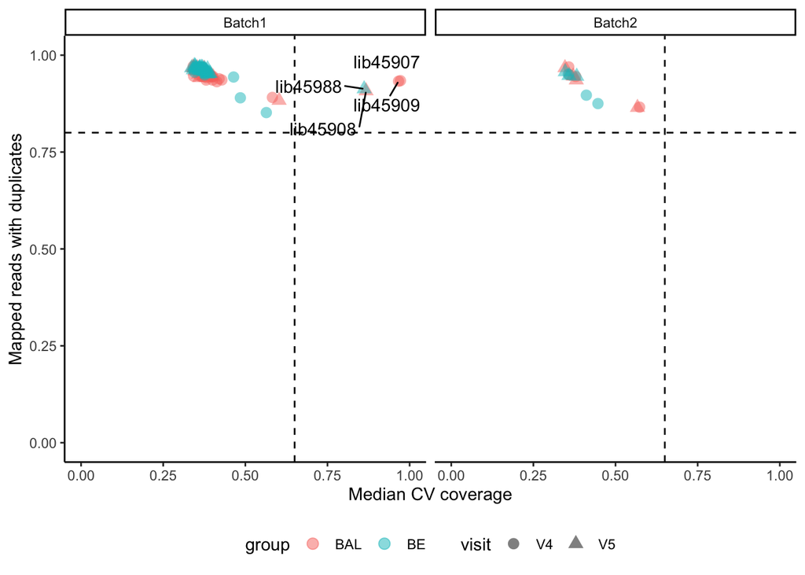

#### Total aligned counts

Assess aligned counts per library. Higher counts indicate high coverage and are preferred. Plot total counts per library. Libraries outside cutoffs are labeled as “questionable”. The minimum total sequences cutoff set above is indicated by a horizontal line.

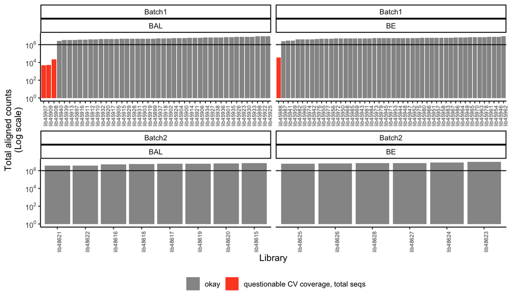

## Filter by library coverage

Using the cutoff defined above, remove libraries with

- median CV coverage $\geq$ 0.65
- mapped reads with duplicates $\leq$ 0.8
- total sequences $\leq$ 1,000,000

```r
#Metadata
meta.filter <- meta.all.format %>%
  filter(median_cv_coverage < CV.cut) %>%
  filter(mapped_reads_w_dups > align.cut) %>%
  filter(total_sequences > count.cut)

#Count data
counts.pc.filter <- counts.pc %>%
  # Keep libraries (columns) remaining filtered metadata table (rows)
  dplyr::select(geneName, as.character(meta.filter$libID))

# No change in key as no genes were removed from the count data
```

This removed 4 libraries.

```r
#save
save(counts.pc.filter, meta.filter,
     file="data_raw/counts.pc.filter.RData")
```

## Assess PCA

### Variables of interest

If one or more variables of interest represents significant variation in the data, consider further filtering and normalizing separately. This is most common when multiple sample or cell types exist in the data set.

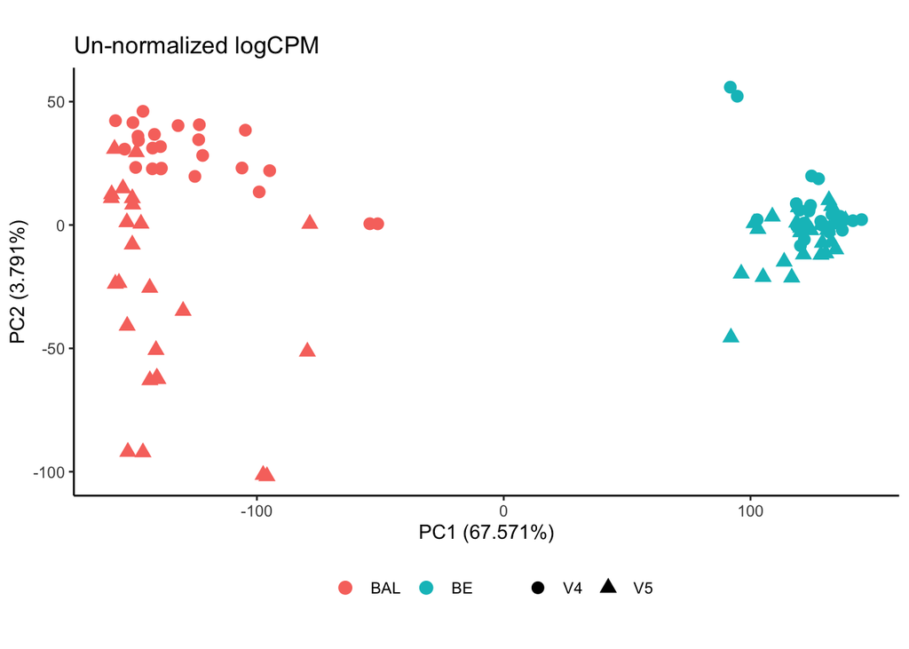

### Batch effects

Samples with poor-quality plus 10 additional duplicates were re-sequenced in batch 2. Check for batch effects. There is also one donor whose BE samples were duplicate sequenced in batch 1.

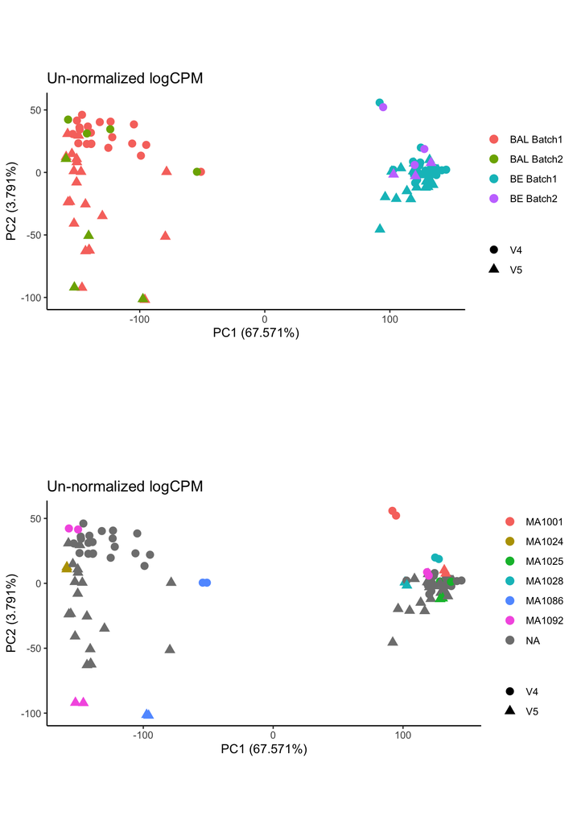

| donorID | group | visit | batch | libID | median_cv_coverage | mapped_reads_w_dups | total_sequences |
| --- | --- | --- | --- | --- | --- | --- | --- |
| MA1001 | BE | V4 | Batch1 | lib45941 | 0.563845 | 0.8518308 | 2731932 |
|  |  | V4 | Batch2 | lib48623 | 0.446494 | 0.8750285 | 9738791 |
|  |  | V5 | Batch1 | lib45942 | 0.393196 | 0.9528393 | 4085240 |
|  |  | V5 | Batch2 | lib48624 | 0.346918 | 0.9569091 | 7941573 |
| MA1024 | BAL | V5 | Batch1 | lib45910 | 0.391962 | 0.9464780 | 4084940 |
|  |  | V5 | Batch2 | lib48618 | 0.371144 | 0.9460996 | 5539599 |
| MA1025 | BE | V4 | Batch1 | lib45957 | 0.353779 | 0.9712901 | 5815858 |
|  |  | V4 | Batch1 | lib45977 | 0.369473 | 0.9694089 | 4615876 |
|  |  | V5 | Batch1 | lib45958 | 0.386459 | 0.9544345 | 5983734 |
|  |  | V5 | Batch1 | lib45978 | 0.347462 | 0.9718227 | 6998641 |
| MA1028 |  | V4 | Batch1 | lib45959 | 0.484826 | 0.8899572 | 2946195 |
|  |  | V4 | Batch2 | lib48625 | 0.411143 | 0.8967289 | 5978200 |
|  |  | V5 | Batch1 | lib45960 | 0.384679 | 0.9516666 | 4026071 |
|  |  | V5 | Batch2 | lib48626 | 0.358314 | 0.9474128 | 6325042 |
| MA1086 | BAL | V4 | Batch1 | lib45933 | 0.341336 | 0.9713428 | 7563305 |
|  |  | V4 | Batch2 | lib48619 | 0.357569 | 0.9696546 | 5952804 |
|  |  | V5 | Batch1 | lib45934 | 0.344018 | 0.9674608 | 6208588 |
|  |  | V5 | Batch2 | lib48620 | 0.346127 | 0.9675172 | 6688084 |
| MA1092 |  | V4 | Batch1 | lib45939 | 0.582305 | 0.8908990 | 3309344 |
|  |  | V4 | Batch2 | lib48621 | 0.573289 | 0.8658478 | 3600638 |
|  |  | V5 | Batch1 | lib45940 | 0.602727 | 0.8832868 | 2723083 |
|  |  | V5 | Batch2 | lib48622 | 0.566723 | 0.8650464 | 3695587 |
|  | BE | V4 | Batch1 | lib45987 | 0.464199 | 0.9435388 | 2379917 |
|  |  | V4 | Batch2 | lib48627 | 0.356476 | 0.9506399 | 6928151 |

We see that samples group by sample, not batch. Since duplicate samples have high-quality metrics in both batches (above), their batch 1 sample will be retained. The 4 additional samples in batch 2 will be retained as their batch 1 libraries failed quality filtering.

### PCA outliers

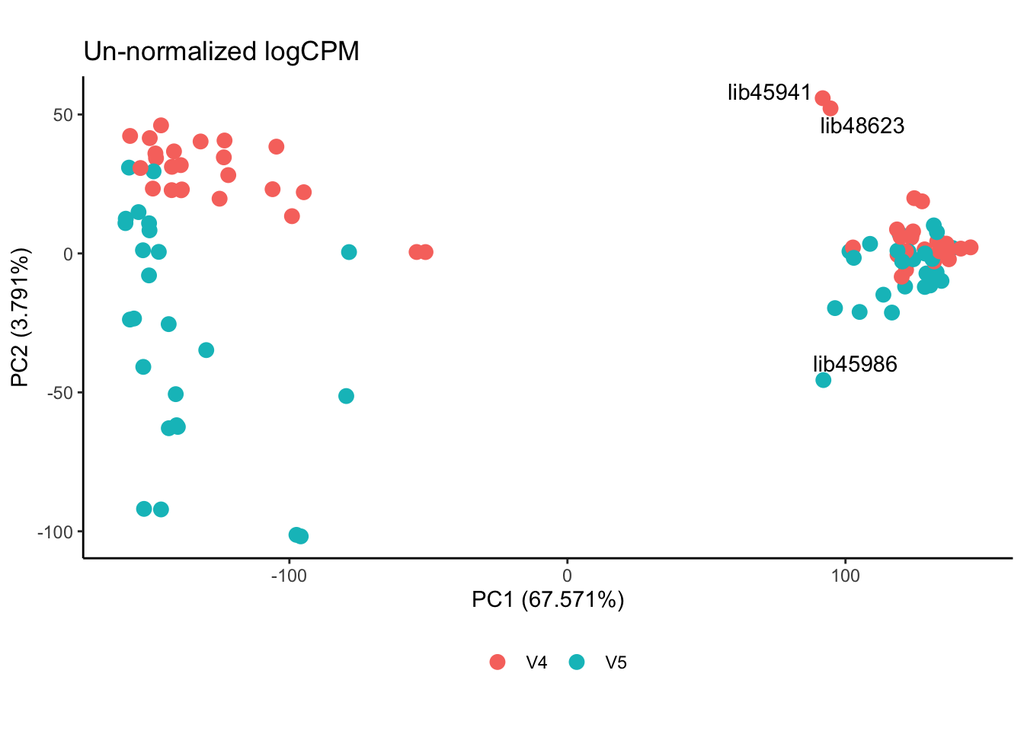

Libraries that are > 3 standard deviations away of their group (BAL/BE + V4/V5) mean on PC1 or PC2 are labeled. We see no outliers in BAL samples but 3 libraries (corresponding two 2 samples) in BE. Verify outlier sample quality below.

| libID | group | donorID | visit | median_cv_coverage | mapped_reads_w_dups | total_sequences |
| --- | --- | --- | --- | --- | --- | --- |
| lib45941 | BE | MA1001 | V4 | 0.563845 | 0.8518308 | 2731932 |
| lib48623 | BE | MA1001 | V4 | 0.446494 | 0.8750285 | 9738791 |
| lib45986 | BE | MA1086 | V5 | 0.361598 | 0.9684298 | 6283562 |

## Filter duplicates and outliers

```r
#Metadata
dedup <- meta.filter %>%
  mutate(dupID = paste(group, donorID, visit, sep="_")) %>%
  filter(dupID %in% dups) %>%
  filter(batch == "Batch1") %>%
  #remove 1025 BE samples duplicate in batch 1
  filter(libID %notin% c("lib45977","lib45978"))

meta.filter.dedup <- meta.filter %>%
  mutate(dupID = paste(group, donorID, visit, sep="_")) %>%
  filter(dupID %notin% dups) %>%
  bind_rows(dedup) %>%
  #outliers
  filter(libID %notin% c("lib45941", "lib48623", "lib45986"))

#Count data
counts.pc.filter.dedup <- counts.pc.filter %>%
  # Keep libraries (columns) remaining filtered metadata table (rows)
  dplyr::select(geneName, as.character(meta.filter.dedup$libID))
```

This removed 14 libraries.

## Separate BAL and BE

Given the large differences in BAL and BE samples, gene filtering and normalization will be completed separately for each sample type.

```r
meta.BAL.filter.dedup <- meta.filter.dedup %>%
  filter(group == "BAL")

counts.BAL.pc.filter.dedup <- counts.pc.filter.dedup %>%
  select(geneName, all_of(meta.BAL.filter.dedup$libID))

meta.BE.filter.dedup <- meta.filter.dedup %>%
  filter(group == "BE")

counts.BE.pc.filter.dedup <- counts.pc.filter.dedup %>%
  select(geneName, all_of(meta.BE.filter.dedup$libID))
```

Create DGEList objects

```r
dat.BAL <- DGEList(
  #count table. move gene names to column names
  counts=as.matrix(column_to_rownames(counts.BAL.pc.filter.dedup,
                                      "geneName")),
  #metadata
  samples=meta.BAL.filter.dedup,
  #keep genes in count table
  genes=key.pc)

####
dat.BE <- DGEList(
  #count table. move gene names to column names
  counts=as.matrix(column_to_rownames(counts.BE.pc.filter.dedup,
                                      "geneName")),
  #metadata
  samples=meta.BE.filter.dedup,
  #keep genes in count table
  genes=key.pc)
```

## Filter rare genes

The raw gene sets contain highly variable, low abundance/rare genes.

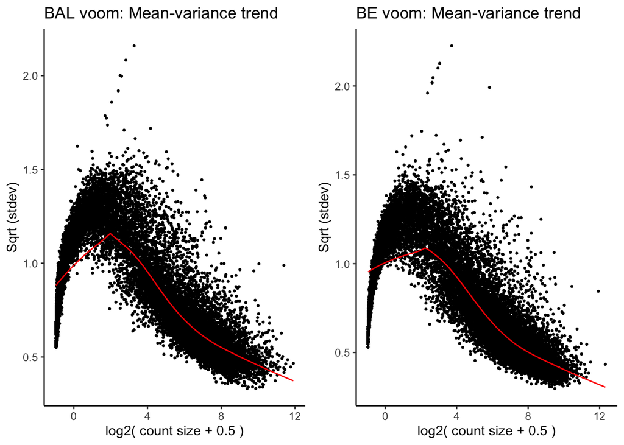

Filter to genes with at least 1 CPM in at least 10% of samples.

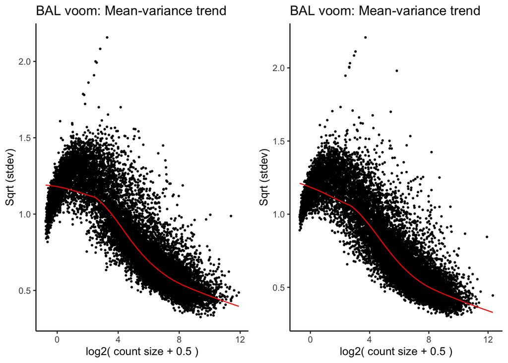

```r
rare.gene.filter(dat = dat.BAL,
                 min.pct = 10,
                 min.CPM = 1,
                 name = 'dat.BAL.abund')
####
rare.gene.filter(dat = dat.BE,
                 min.pct = 10,
                 min.CPM = 1,
                 name = 'dat.BE.abund')
```

This removes 4766 (~ 25%) genes in BAL samples and 3102 (~ 16%) genes in BE samples.

## TMM normalization

Calculate factors to scale library sizes.

```r
dat.BAL.abund.norm <- calcNormFactors(dat.BAL.abund)
dat.BE.abund.norm <- calcNormFactors(dat.BE.abund)
```

## Normalize with voom

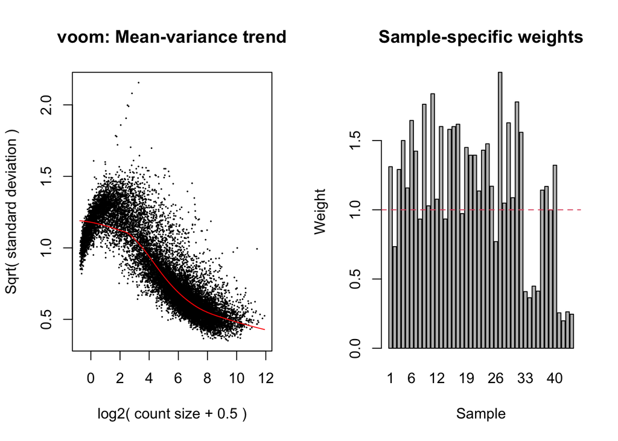

```r
dat.BAL.abund.norm.voom <- voomWithQualityWeights(
                          dat.BAL.abund.norm,
                          design=model.matrix(~visit,
                          data=dat.BAL.abund.norm$samples),
                                       plot=TRUE)
```

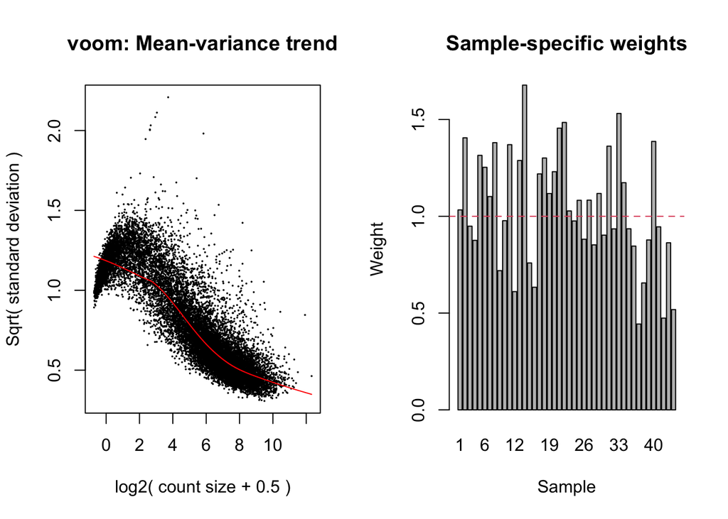

```r
dat.BE.abund.norm.voom <- voomWithQualityWeights(
                          dat.BE.abund.norm,
                          design=model.matrix(~visit,
                          data=dat.BE.abund.norm$samples),
                                       plot=TRUE)
```

# Summarize cleaning

Libraries removed

| group | donorID | visit | batch | libID | filter | recovered by duplicate |
| --- | --- | --- | --- | --- | --- | --- |
| BAL | MA1022 | V4 | Batch1 | lib45907 | CV coverage, total seqs | Y |
|  |  | V5 | Batch1 | lib45908 | CV coverage, total seqs | Y |
|  | MA1024 | V4 | Batch1 | lib45909 | CV coverage, total seqs | Y |
|  |  | V5 | Batch2 | lib48618 | duplicate sample | Y |
|  | MA1086 | V4 | Batch2 | lib48619 | duplicate sample | Y |
|  |  | V5 | Batch2 | lib48620 | duplicate sample | Y |
|  | MA1092 | V4 | Batch2 | lib48621 | duplicate sample | Y |
|  |  | V5 | Batch2 | lib48622 | duplicate sample | Y |
| BE | MA1001 | V4 | Batch1 | lib45941 | PCA outlier |  |
|  |  | V4 | Batch2 | lib48623 | PCA outlier |  |
|  |  | V5 | Batch2 | lib48624 | duplicate sample | Y |
|  | MA1025 | V4 | Batch1 | lib45977 | duplicate sample | Y |
|  |  | V5 | Batch1 | lib45978 | duplicate sample | Y |
|  | MA1028 | V4 | Batch2 | lib48625 | duplicate sample | Y |
|  |  | V5 | Batch2 | lib48626 | duplicate sample | Y |
|  | MA1086 | V5 | Batch1 | lib45986 | PCA outlier |  |
|  | MA1092 | V4 | Batch2 | lib48627 | duplicate sample | Y |
|  |  | V5 | Batch1 | lib45988 | CV coverage, total seqs | Y |

Final samples

| group | visit | n |
| --- | --- | --- |
| BAL | V4 | 22 |
| BAL | V5 | 22 |
| BE | V4 | 22 |
| BE | V5 | 22 |

## PCA final data set

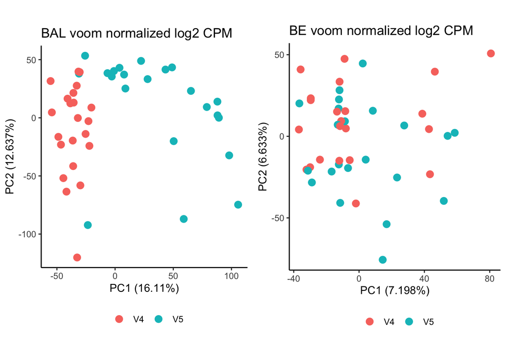

## Save data

Write as RData

```r
dat.BAL <- dat.BAL.abund.norm.voom
save(dat.BAL,file="data_clean/P337_BAL_data.RData")

dat.BE <- dat.BE.abund.norm.voom
save(dat.BE, file="data_clean/P337_BE_data.RData")
```

Write counts as table.

```r
write_csv(as.data.frame(dat.BAL.abund.norm.voom$E),
          "data_clean/P337_BAL_counts_voom.csv")
write_csv(as.data.frame(dat.BE.abund.norm.voom$E),
          "data_clean/P337_BE_counts_voom.csv")
```